# FCSimple workflow

Josh Simmons

Vanderbilt University Medical Center  
joshua.d.simmons@vumc.org

Abstract

FCSimple workflow

Load the library. Dependencies will be loaded as needed by the package functions. See github for full list of dependencies required to run all supported methods.

```r
library(FCSimple)
```

Start by getting the paths to a few sample FCS files included with the FCSimple library. These are longitudinal data on pbmcs harvested from a single human source.

```r
vignette_files <- fcs_load_data()
```

Next, create a list object using the fcs_join function. Note, for any function, you can view the function arguments like this:

```r
args(fcs_join)
```

```
## function (files, apply_transform = TRUE, instrument_type = c("cytof",
##     "flow"), use_descriptive_column_names = TRUE, transform_function = NULL,
##     transform_type = c("asinh", "biexp", "hyperlog"), asinh_transform_cofactor = 5,
##     biexp_transform_pos = 4.5, biexp_transform_neg = 0, biexp_transform_width = -10,
##     hyperlog_transform_T = 1e+05, hyperlog_transform_M = 5, hyperlog_transform_W = 0.001,
##     hyperlog_transform_A = 2, transform_per_channel = TRUE, downsample_size = c(NA,
##         25000))
## NULL
```

You should either (1) set the transform parameters manually and set transform_per_channel = FALSE or (2) use the default function arguments and set transform_per_channel = TRUE to use the shiny app to interactively set your transforms. Default is TRUE. Here I will specify transform parameters that are generally acceptable for the analysis of any cytof data. If using fluorescence data and the “asinh” transform_type, consider setting the asinh_transform_cofactor to around 250. Default asinh_transform_cofactor is 5.

```r
fcs_obj <- fcs_join(files = vignette_files,
                    instrument_type = "cytof",
                    transform_type = "asinh",
                    asinh_transform_cofactor = 5,
                    downsample_size = NA,
                    transform_per_channel = FALSE)
```

The list object will include, by default, (1) the transformed data under the data element, (2) the raw, un-transformed data under the raw element, and (3) the file source of each cell.

```r
summary(fcs_obj)
```

```
##        Length  Class  Mode
## data   2400000 -none- numeric
## raw    2400000 -none- numeric
## source   75000 -none- character
```

```r
head(fcs_obj$data)
```

```
##      209Bi_CD16 160Dy_CD28 161Dy_Ki-67 162Dy_CD69 163Dy_BTLA 164Dy_CXCR5
## [1,]  0.1664629  1.8827673   0.4133655  2.8579149 0.98417221  0.03767222
## [2,]  0.0000000  3.1519664   0.6117311  0.2381793 0.84092867  3.67500762
## [3,]  0.0000000  3.2762591   0.0000000  1.9265671 0.07726993  0.00000000
## [4,]  0.8316176  3.1748060   0.3151895  0.0000000 0.00000000  0.00000000
## [5,]  0.2767328  0.7871861   0.3010540  0.0000000 0.86362465  0.00000000
## [6,]  2.8673796  2.1045512   0.0000000  1.8938761 0.00000000  0.47653161
##      167Er_CD27 168Er_CD138 151Eu_ICOS 153Eu_CCR2 154Gd_TIGIT 155Gd_PD-1
## [1,]   4.471817   1.6308259 0.06925633   1.295987    0.000000 0.00000000
## [2,]   4.056417   0.0000000 1.46689135   0.000000    1.212318 0.00000000
## [3,]   4.275751   0.0000000 0.55066885   0.000000    0.000000 0.07109839
## [4,]   2.011987   0.0000000 0.61037538   2.436921    0.000000 0.51364625
## [5,]   1.803493   0.0000000 1.19395368   2.115577    0.000000 0.07008688
## [6,]   4.434741   0.7448335 0.00000000   0.000000    0.000000 0.00000000
##      156Gd_CXCR3   158Gd_OX40 165Ho_CD19 175Lu_CCR4 176Lu_CD127 144Nd_CD38
```

[output cut: 27 more lines]

```r
table(fcs_obj$source)
```

```
##
## cytof_V1.fcs cytof_V2.fcs cytof_V3.fcs
##        25000        25000        25000
```

For readability, I will trim the metal names off of the data matrix column names.

```r
colnames(fcs_obj$data) <- gsub(pattern = "^.+_",
                               replacement = "",
                               x = colnames(fcs_obj$data))
head(fcs_obj$data,3)
```

```
##           CD16     CD28     Ki-67      CD69       BTLA      CXCR5     CD27
## [1,] 0.1664629 1.882767 0.4133655 2.8579149 0.98417221 0.03767222 4.471817
## [2,] 0.0000000 3.151966 0.6117311 0.2381793 0.84092867 3.67500762 4.056417
## [3,] 0.0000000 3.276259 0.0000000 1.9265671 0.07726993 0.00000000 4.275751
##         CD138       ICOS     CCR2    TIGIT       PD-1    CXCR3         OX40
## [1,] 1.630826 0.06925633 1.295987 0.000000 0.00000000 3.772203 0.0000000000
## [2,] 0.000000 1.46689135 0.000000 1.212318 0.00000000 1.338082 0.0002456133
## [3,] 0.000000 0.55066885 0.000000 0.000000 0.07109839 0.000000 0.0969486377
##            CD19 CCR4    CD127       CD38      CD4      CD8      CD14 CCR6
## [1,] 0.01283975    0 2.864839 0.04172902 0.000000 4.834640 0.0000000    0
## [2,] 0.00000000    0 3.356162 1.09767848 4.569840 1.117731 0.9673013    0
## [3,] 0.00000000    0 3.011651 2.68058190 4.465035 1.263861 0.0000000    0
##        CD45RO CD86      CD21     CCR7     CD25      CD3 CD20      CD57 CD137
## [1,] 2.668059    0 0.0000000 2.927961 0.000000 4.170869    0 0.0000000     0
## [2,] 4.647468    0 0.3652282 3.128819 1.392163 3.506683    0 0.2238209     0
## [3,] 0.000000    0 0.0000000 4.137628 0.000000 4.147803    0 0.2716014     0
##      HLA-DR
## [1,]      0
## [2,]      0
## [3,]      0
```

I can check the distributions of the transformed data if I want using fcs_plot_distribution. The figure will be written to whatever is specified using the outdir argument.

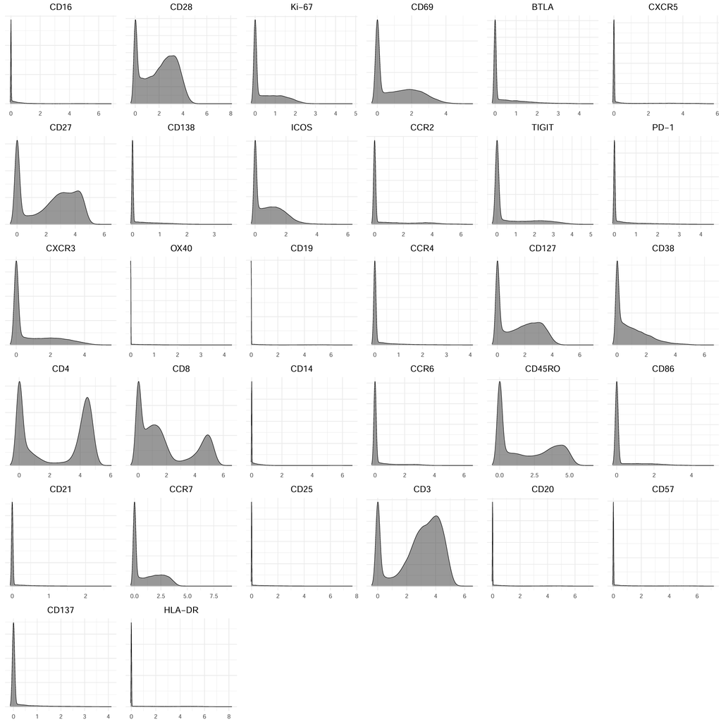

```r
fcs_plot_distribution(fcs_join_obj = fcs_obj,
                      separate_by = "none",
                      outdir = "./vignette_outs",
                      add_timestamp = FALSE)
```

The data can be clustered using the fcs_cluster function. Make sure to specify a language, either “R” or “Python”. Python will require python to be on your system $PATH and the various additional dependencies (see github). The leiden algorithm for clustering is recommended. The “git” method is largely untested and may fail to run. The default number of cores to use for nearest neighbor searching is half of your system’s available cores. This number can be increased or decreased using the num_cores argument. See args(fcs_cluster) for additional options. The results of fcs_cluster will be appended to the fcs_obj list. Note that the nearest neighbor search will only be run once so re-running with different resolutions will take much less time after initially calling fcs_cluster. I specify 30 nearest neighbors here but this number can be changed by altering the adjacency_knn argument value.

```r
fcs_obj <- fcs_cluster(fcs_join_obj = fcs_obj,
                       language = "Python",
                       algorithm = "leiden",
                       leiden_louvain_resolution = 1,
                       adjacency_knn = 30,
                       search_method = "RANN",
                       search_only = FALSE)
```

```
## [1] "searching with 12 cores"
```

A quick summary of the list object after the nearest neighbor search and clustering has finished reveals the addition of new elements to the list.

```r
summary(fcs_obj)
```

```
##                  Length  Class     Mode
## data             2400000 -none-    numeric
## raw              2400000 -none-    numeric
## source             75000 -none-    character
## adjacency_matrix      NA ngCMatrix S4
## leiden                 2 -none-    list
```

The cluster numbers can be easily accessed. Here I print a table of the identified clusters.

```r
table(fcs_obj$leiden$clusters)
```

```
##
##    0    1    2    3    4    5    6    7    8    9   10   11   12   13   14   15
## 8896 7612 7522 7160 6982 6839 6528 6184 5784 2332 1736 1499 1454 1427 1342  875
##   16   17
##  597  231
```

A good followup to clustering is running a dimension reduction on the data to better visualize it. Here I run the UMAP algorithm using the Python language. tSNE is also supported and these can be run in R instead of Python if desired. Again, the default number of cores to use is half of the available system cores but this can be changed by altering the nthread argument. It may be useful to try different umap_min_dist or tsne_perplexity values depending on what reduction algorithm is used. It generally makes sense to use the same number of nearest neighbors as was used for clustering.

```r
fcs_obj <- fcs_reduce_dimensions(fcs_join_obj = fcs_obj,
                                 algorithm = "umap",
                                 language = "Python",
                                 umap_nn = 30,
                                 umap_min_dist = 0.1)
```

Since the data has been clustered and dimension reduction was run, we can take a look at the results. Note that if you would rather just save the figure to file, set return_plot to FALSE. Here I set it to TRUE and plot it below. If return_plot is set to FALSE, do not assign the results to a variable. Since I set return_plot to TRUE here, I assign the output to a variable, my_umap.

```r
my_umap <- fcs_plot_reduction(fcs_join_obj = fcs_obj,
                   algorithm = "leiden",
                   reduction = "umap",
                   return_plot = TRUE)
```

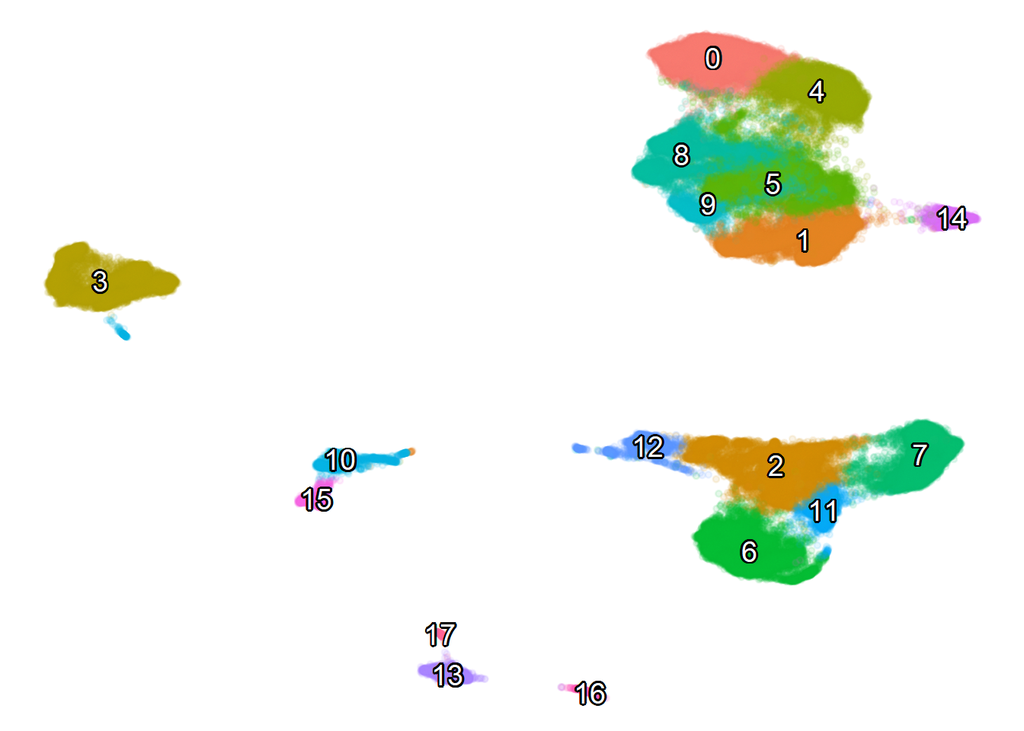

```r
my_umap
```

You can visualize the marker expression patterns for the clusters. It can be useful to append the resolution used to find the clusters to the file name with append_file_string.

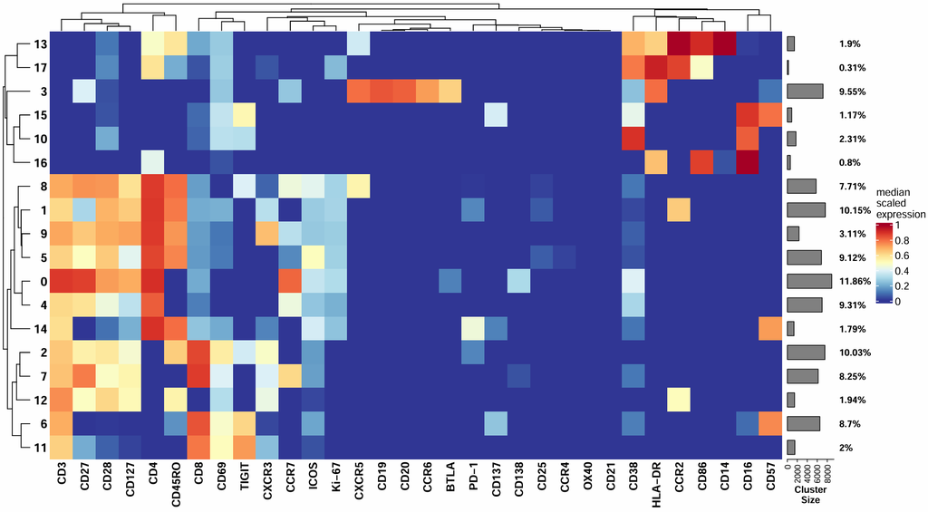

```r
fcs_obj <- fcs_cluster_heatmap(fcs_join_obj = fcs_obj,
                               algorithm = "leiden")
fcs_plot_heatmap(fcs_join_obj = fcs_obj,
                 algorithm = "leiden",
                 outdir = "./vignette_outs",
                 add_timestamp = FALSE,
                 append_file_string = "res1")
```

There are several ways to visualize differences between groups. Since there are only three groups here, I will make edits to the source element to demonstrate the methods. I’ll save the original source information for later.

```r
original_source <- fcs_obj$source
table(original_source)
```

```
## original_source
## cytof_V1.fcs cytof_V2.fcs cytof_V3.fcs
##        25000        25000        25000
```

```r
split_src <- split(x = original_source, f = original_source)
split_source <- function(arg1, n = 10) {
  arg_seq <- as.integer(seq(from = 1, to = 25000, length.out = n))
  group_str <- rep(LETTERS[(1:length(arg_seq))-1],arg_seq[2])
  new_pattern <- paste0(arg1,"_",group_str)
  set.seed(123)
  new_pattern_sampled <- new_pattern[sample(1:length(new_pattern),
                                            size = length(new_pattern),
                                            replace = FALSE)]
  return(new_pattern_sampled[1:length(arg1)])
}
source_sample <- lapply(X = split_src, FUN = split_source)
new_sources <- unlist(source_sample)
fcs_obj$source <- gsub("\\.fcs", "", new_sources)
table(fcs_obj$source)
```

```
##
## cytof_V1_A cytof_V1_B cytof_V1_C cytof_V1_D cytof_V1_E cytof_V1_F cytof_V1_G
##       2778       2778       2777       2778       2778       2777       2778
## cytof_V1_H cytof_V1_I cytof_V2_A cytof_V2_B cytof_V2_C cytof_V2_D cytof_V2_E
##       2778       2778       2778       2778       2777       2778       2778
## cytof_V2_F cytof_V2_G cytof_V2_H cytof_V2_I cytof_V3_A cytof_V3_B cytof_V3_C
##       2777       2778       2778       2778       2778       2778       2777
## cytof_V3_D cytof_V3_E cytof_V3_F cytof_V3_G cytof_V3_H cytof_V3_I
##       2778       2778       2777       2778       2778       2778
```

Prior to testing, the cluster abundances must be calculated. The results will be added to the list object.

```r
fcs_obj <- fcs_calculate_abundance(fcs_join_obj = fcs_obj,
                                   report_algorithm = "leiden",
                                   report_as = "frequency")
```

To prepare for testing, split the patient IDs up, based on how they are listed in the source list element. I also pick the colors that will be used to differentiate the groups visually. The names() of each list input, compare_v1v3_id and compare_v1v3_col here, must match. If a paired test should be done on these groups, the order of the IDs matters in the same way it would if doing wilcox.test(x, y, paired = TRUE).

```r
unique_id <- unique(fcs_obj$source)
compare_v1v3_id <- list(V1 = unique_id[grep("V1", unique_id)],
                        V3 = unique_id[grep("V3", unique_id)])
compare_v1v3_col <- list(V1 = "seagreen",
                         V3 = "coral")
test_groups <- list(names(compare_v1v3_id))
```

```r
compare_v1v3_id
```

```
## $V1
## [1] "cytof_V1_A" "cytof_V1_D" "cytof_V1_G" "cytof_V1_F" "cytof_V1_E"
## [6] "cytof_V1_I" "cytof_V1_C" "cytof_V1_H" "cytof_V1_B"
##
## $V3
## [1] "cytof_V3_A" "cytof_V3_D" "cytof_V3_G" "cytof_V3_F" "cytof_V3_E"
## [6] "cytof_V3_I" "cytof_V3_C" "cytof_V3_H" "cytof_V3_B"
```

```r
compare_v1v3_col
```

```
## $V1
## [1] "seagreen"
##
## $V3
## [1] "coral"
```

```r
test_groups
```

```
## [[1]]
## [1] "V1" "V3"
```

Now run the test. The plotted results of the test will be appended to the list object.

```r
fcs_obj <- fcs_test_clusters(fcs_join_obj = fcs_obj,
                             compare_list = compare_v1v3_id,
                             color_list = compare_v1v3_col,
                             comparisons = test_groups,
                             algorithm = "leiden",
                             denominator_cell_type = "lymphocytes",
                             paired_test = FALSE)
```

```
## [1] "test results saved in object under: fcs_join_obj[['leiden']][['cluster_test_results']]"
```

We can take a look at the various additions to the list object running summary on the list.

```r
summary(fcs_obj)
```

```
##                  Length  Class     Mode
## data             2400000 -none-    numeric
## raw              2400000 -none-    numeric
## source             75000 -none-    character
## adjacency_matrix      NA ngCMatrix S4
## leiden                 4 -none-    list
## umap                   2 -none-    list
## leiden_heatmap         3 -none-    list
```

The cluster numbers, argument settings used to cluster the data, cluster abundances, and boxplots with test statistics are all held within the leiden element and can easily be accessed.

```r
summary(fcs_obj$leiden)
```

```
##                      Length Class  Mode
## clusters             75000  -none- numeric
## settings                 4  -none- list
## abundance              486  -none- numeric
## cluster_test_results    18  -none- list
```

To print all test plots to a file, one could do something like this.

```r
pdf(file = "./vignette_outs/leiden_cluster_testing_res1.pdf", width = 10, height = 5)
lapply(X = fcs_obj$leiden$cluster_test_results, FUN = function(x) x)
dev.off()
```

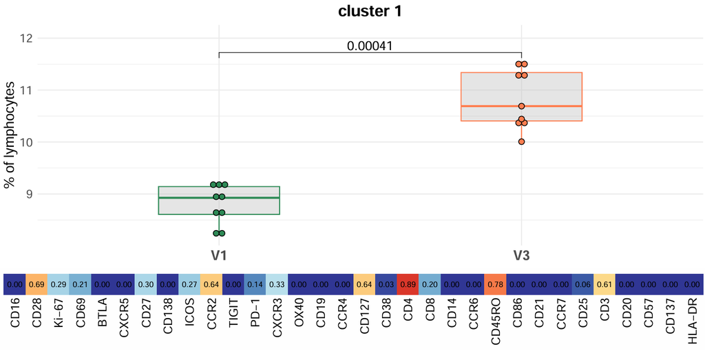

I’ll return the original source strings back to the object before continuing.

```r
fcs_obj$source <- original_source
table(fcs_obj$source)
```

```
##
## cytof_V1.fcs cytof_V2.fcs cytof_V3.fcs
##        25000        25000        25000
```

There are some other supported visualization methods that may be useful when attempting to understand the data better. First, you can create a representation of the difference in the distribution of the data points on the UMAP between any two groups. The setup is similar to before. Since I added the original source names back into the object, I’ll redo the setup for the next visualization.

```r
unique_id <- unique(fcs_obj$source)
umap_v1v3_id <- list(V1 = unique_id[grep("V1", unique_id)],
                     V3 = unique_id[grep("V3", unique_id)])
umap_v1v3_col <- list(V1 = "seagreen",
                      V3 = "coral")
umap_groups <- list(names(compare_v1v3_id))
```

```r
umap_v1v3_id
```

```
## $V1
## [1] "cytof_V1.fcs"
##
## $V3
## [1] "cytof_V3.fcs"
```

```r
umap_v1v3_col
```

```
## $V1
## [1] "seagreen"
##
## $V3
## [1] "coral"
```

```r
umap_groups
```

```
## [[1]]
## [1] "V1" "V3"
```

This function will save several outputs to the specified outdir. It’s not a statistically sound way to make comparisons, it simply concatenates each group separately and highlights areas where the peaks and valleys of data point densities on the UMAP (or tSNE) differ. It can be useful for hypothesis testing and often does mirror the statistical returns given by fcs_test_clusters. Under the hood, MASS::kde2d is called on both groups and the difference is taken. This is then plotted and values are mapped to a color gradient where the midpoint always means there is no difference between the groups. Units are masked since they are relative to the n_kde and hard to interpret. The colors are mapped to a linear scale though so no transformation is applied to the calculated differences.

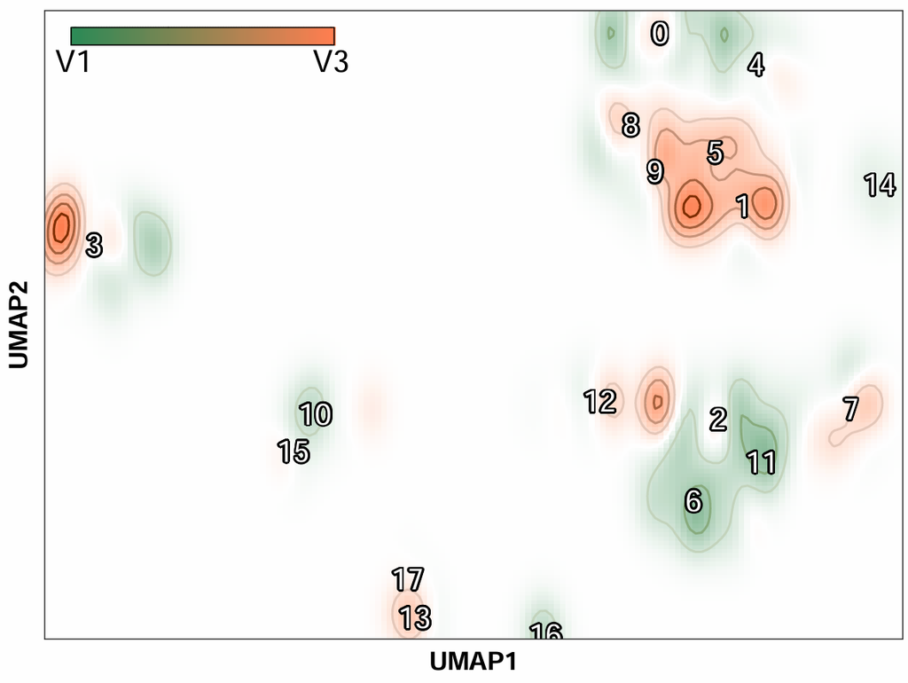

```r
fcs_plot_reduction_difference(fcs_join_obj = fcs_obj,
                              reduction = "umap",
                              compare_list = umap_v1v3_id,
                              color_list = umap_v1v3_col,
                              n_kde = 150,
                              outdir = "./vignette_outs",
                              add_timestamp = FALSE,
                              cluster_algorithm = "leiden",
                              legend_orientation = "horizontal",
                              figure_width = 6,
                              figure_height = 4.5)
```

There is a method to visualize marker distributions on the dimension reduction plots. This may help guide what resolution (or equivalent) might be appropriate for the data. This function will save the plots to disk at the specified outdir.

```r
fcs_project_parameters(fcs_join_obj = fcs_obj,
                       reduction = "umap",
                       parameters = "all",
                       outdir = "./vignette_outs",
                       sample_size = 50000)
```

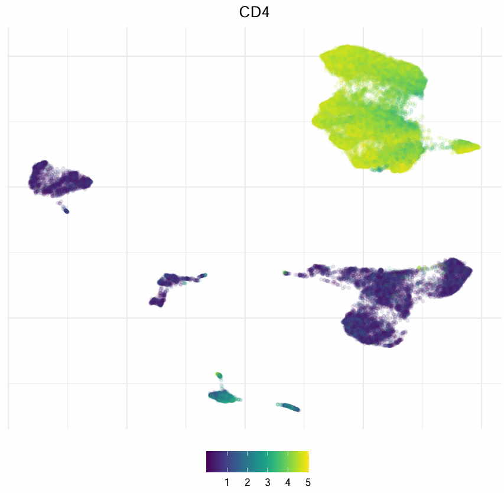

Methods that support batch correction should be added soon.